# Prime-seq data human T clustering

Daniel Brown

2024-11-20

# Intro Human T cell clustering

## Notebook aim

Focus analysis only on Yasmin’s samples, excluding my HEK293Ts and NIH3T3s.

Yasmin has human t cells sorted for CD4 and CD8 subsets across multiple days I asked her to prepare a separate plate for each time point for each timepoint. Cells are sorted in media : 2x Qiagen TCL buffer in a 1:1 ratio Therefore I consolidated the timepoints into 2x 96w plates prior to RNA extraction. When I did the extraction I replated into a deep well plate:

### Yasmin notes

These are all samples of T cells that have or haven’t been transduced with a CAR, to look at how their profiles change over the activation/transduction/expansion period. There are CD4 and CD8 T cells from two donors, and everything is done in triplicate (I have attached the plate plan in case you haven’t seen it Ryan).

- D0 – pre-activation
- D1 – post-activation (CD3/28)
- D2 – post-transduction
- D5-D15 – expansion period

Clarification from Ryan Cross:

- Cells are thawed on day 0 and likely to look sick
- Day 1 is T cells when they are happy and healthy = baseline.
- Day 2 is when they are get stimulated and starting to take off .
- Day 5 is considered the peak of stimulation

## Lab notes

- Making the plates https://au-mynotebook.labarchives.com/share/Daniel_RnD_Projects/NDY4LjB8NjgxOTcvMzYwL1RyZWVOb2RlLzM4NDYzNDM1NTh8MTE4OC4w
- The library preparation https://au-mynotebook.labarchives.com/share/Daniel_RnD_Projects/NDc1Ljh8NjgxOTcvMzY2L1RyZWVOb2RlLzQxMTM0Njc2MTJ8MTIwNy44

# Read data

This was generated in *1A_generateSCE-human*

```r
sce <- readRDS(here::here(
   "data/TIRE_Tcell/SCEs/prime_tcell_cluster.sce.rds"
))
sce_orig <- sce

# Convert to ordered factor with numeric day values
sce$Timepoint <- factor(sce$Timepoint,
                       levels = str_sort(unique(sce$Timepoint), numeric = TRUE),
                       ordered = TRUE)

tb <- as_tibble(colData(sce))
```

### View highly expressed genes

- TMSB4X seems like an non-specific immune gene
- The other genes are pretty typical of RNA-Seq as highly expressed genes.

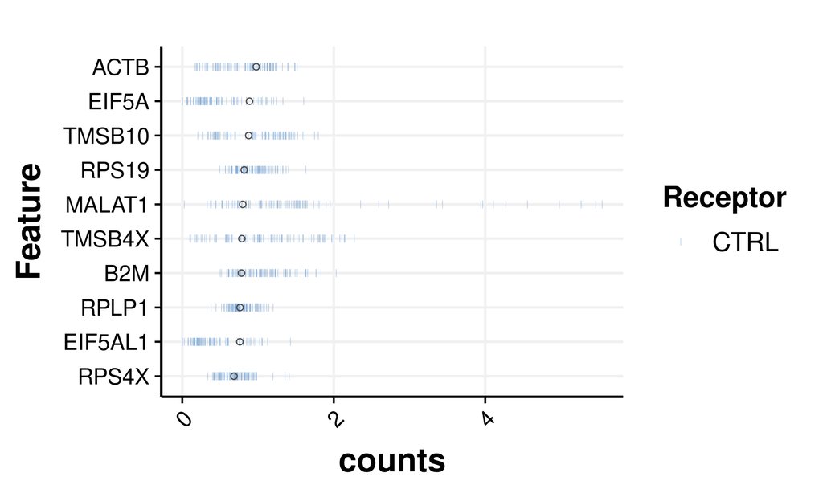

```r
plt1 <- plotHighestExprs(sce, n=10, colour_cells_by = "Receptor") +
  theme_Publication()

plt1
```

Library size normalization and transformation

```r
set.seed(666)

lib.sf <- librarySizeFactors(sce)
sce <- computeSumFactors(sce)
sce <- logNormCounts(sce)
```

## Feature selection

Select the top 1000 most variable genes.

```r
dec.sce <- modelGeneVar(sce)
fit.sce <- metadata(dec.sce)
hvg.sce.var <- getTopHVGs(dec.sce, n=1000)
sce <- runPCA(sce, subset_row=hvg.sce.var, ncomponents=30)
```

Visulaise the fit

```r
tb <- as_tibble(cbind(fit.sce$mean, fit.sce$var))

colnames(tb) <- c("Mean", "Variance")
```

## Visualise mean variance

There are a few number of genes above technical variation but I would not expect to see large biological differences in further analysis.

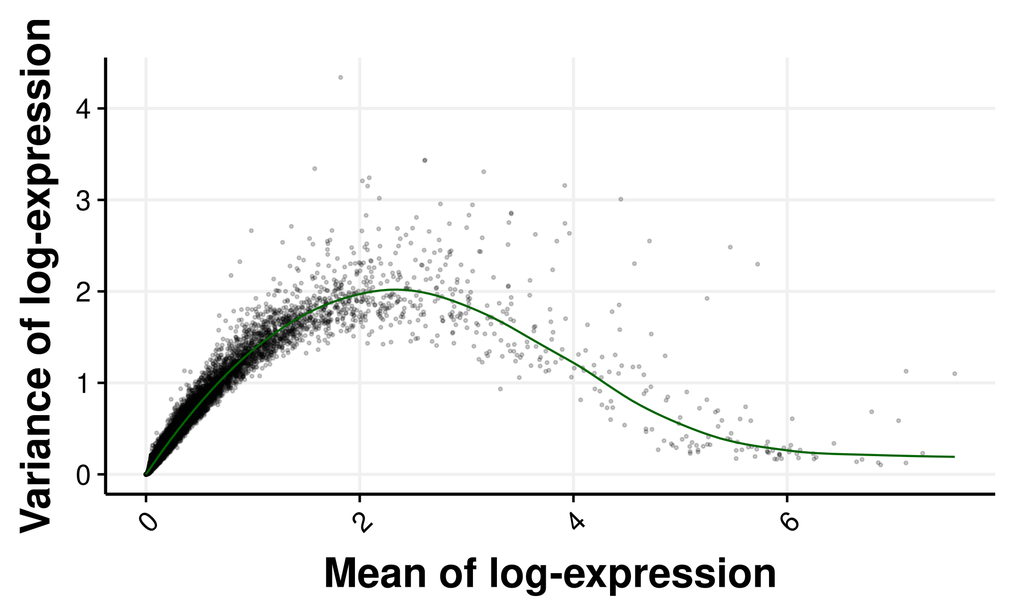

The coloured line represents technical variation

```r
plt2 <- ggplot(tb,
             aes(x = Mean, y= Variance)) +
  geom_point(alpha = 0.2, size=0.5) +
  guides(colour = guide_legend(override.aes = list(size=2, alpha=1))) +
  xlab("Mean of log-expression") +
  ylab("Variance of log-expression") +
  scale_colour_brewer(type="qualitative", palette = "Dark2") +
  geom_function(fun = fit.sce$trend, colour = "darkgreen") +
  theme_Publication(base_size = 16)

plt2
```

## PCA plots

### Days post stimulation CD3 + CD28

- Seems to be the major difference revealed by the PCA.
- PCA 1 has some element of timepoint.
- PCA2 is less clear
- Day 0 which is when the cells are thawed has a lot of variation which one would expect.

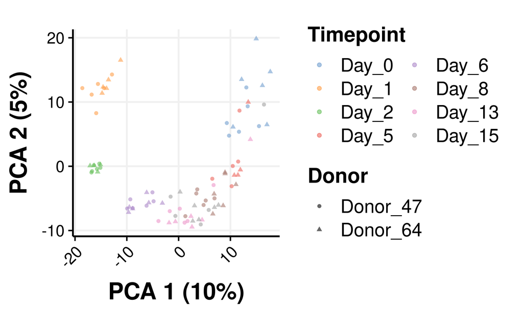

```r
plt4 <- plotPCA(sce, colour_by="Timepoint", shape_by="Donor") +
  guides(colour=guide_legend(ncol=2)) +
  theme_Publication(base_size=18)

plt4
```

### Immune subset

Not as big a difference as I would have expected.

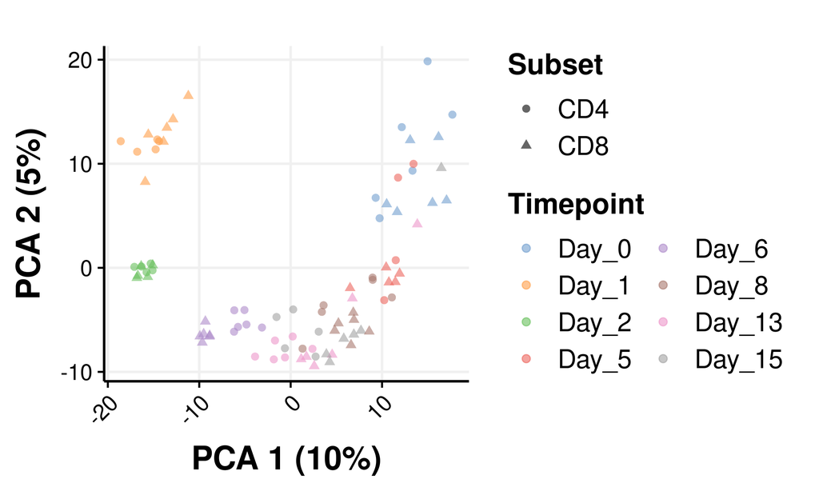

```r
plt5 <- plotPCA(sce, colour_by="Timepoint", shape_by="Subset", point_size=2) +
  guides(colour=guide_legend(ncol=2)) +
  theme_Publication(base_size=16)
plt5
```

### Donor

Slight effect which is typical of omics data.

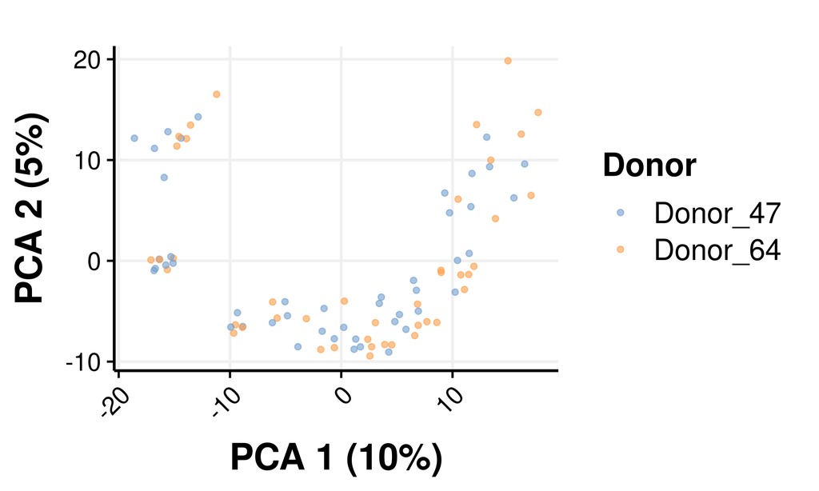

```r
plt3 <- plotPCA(sce, colour_by="Donor") + theme_Publication(base_size=18)

plt3
```

### Genes detected

At timepoint 2 days post activation, control untransduced cells have more genes detected.  
This makes sense that the cells are most supercharged here.

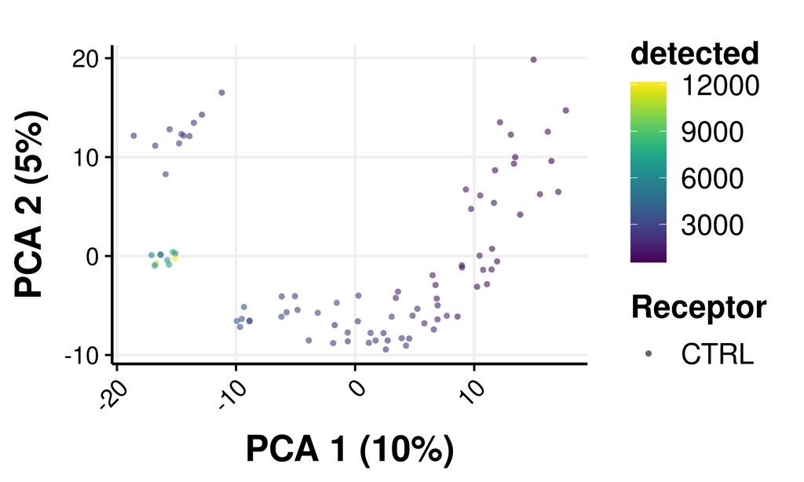

```r
plt6 <- plotPCA(sce, colour_by="detected", shape_by="Receptor") + theme_Publication(base_size=18)
plt6
```

### Variance explained

Keep 20 PCs to focus on the biological variation.

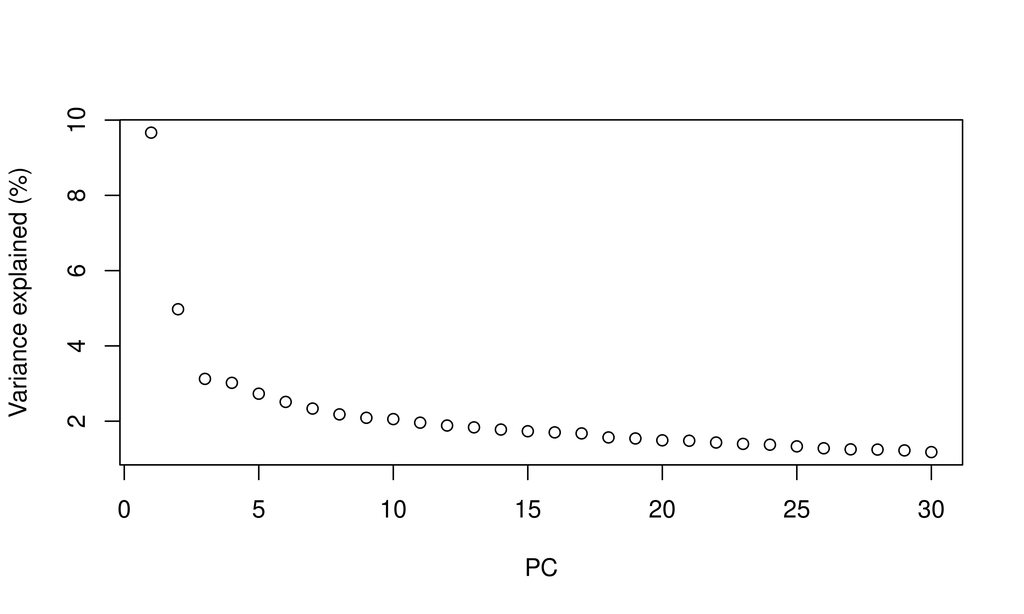

```r
# Percentage of variance explained is tucked away in the attributes.
percent.var <- attr(reducedDim(sce), "percentVar")

plot(percent.var, xlab="PC", ylab="Variance explained (%)")
```

## UMAP

```r
set.seed(100)
sce <- runUMAP(sce, dimred = "PCA", n_dimred=20)
```

### Timepoint

Very curious that day 1 and day 2 has the most dramatic differences and day 0 does not.

In the PCA plots day 0 is more distinct.

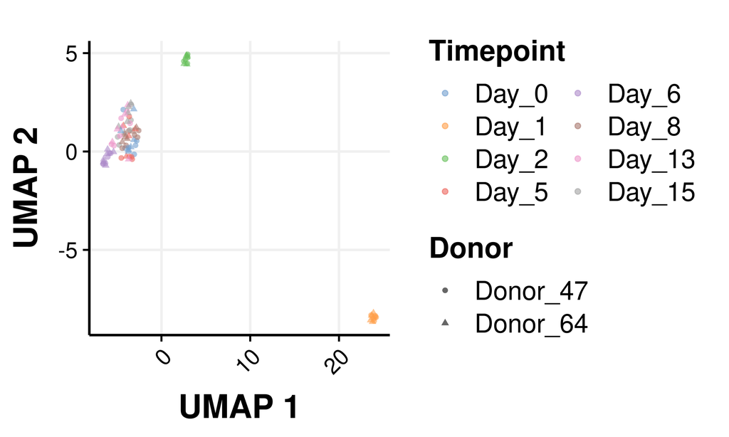

```r
plt10 <- plotReducedDim(sce, dimred="UMAP", colour_by="Timepoint",shape_by="Donor") +
  guides(colour=guide_legend(ncol=2)) +
  theme_Publication(base_size = 18)

plt10
```

## Conclusion

- Timepoint after stimulation is the major difference.
- Minor differences with immune subset

### Next steps

Differential expression testing.